```python
gdp_filename = 'GDP.csv'
population_filename = 'world_population.csv'
pocz = 1970.0
kon = 1999.0
```

# Marcin Socha nr 418253

Na początku zaimportujmy potrzebne biblioteki, pliki z danymi oraz lata, ktorych mają dotyczyć analizy.

```python
import pandas as pd

# Wyświetlenie przekazanych nazw plików
print(f"Wczytano plik GDP: {gdp_filename}")
print(f"Wczytano plik Population: {population_filename}")

# Wyświetlenie wprowadzonych liczb
print(f"Pierwsza liczba: {pocz}")
print(f"Druga liczba: {kon}")

# Wczytywanie plików CSV i wyświetlanie nazw kolumn
try:
    GDP = pd.read_csv(gdp_filename)
    pop = pd.read_csv(population_filename)

    # Wyświetlanie nazw kolumn
    print(f"Kolumny w pliku GDP ({gdp_filename}):")
    print(GDP.columns)

    print(f"Kolumny w pliku Population ({population_filename}):")
    print(pop.columns)

except FileNotFoundError as e:
    print(f"Błąd: {e}")
except pd.errors.EmptyDataError:
    print("Błąd: Jeden z plików CSV jest pusty.")
```

```
Wczytano plik GDP: GDP.csv
Wczytano plik Population: world_population.csv
Pierwsza liczba: 1970.0
Druga liczba: 1999.0
Kolumny w pliku GDP (GDP.csv):
Index(['region', 'id', 'fullName', ' GDP', 'Unnamed: 4'], dtype='object')
Kolumny w pliku Population (world_population.csv):
Index(['Rank', 'CCA3', 'Country/Territory', 'Capital', 'Continent',
       '2022 Population', '2020 Population', '2015 Population',
       '2010 Population', '2000 Population', '1990 Population',
       '1980 Population', '1970 Population', 'Area (km²)', 'Density (per km²)',
       'Growth Rate', 'World Population Percentage'],
      dtype='object')
```

```python
import pandas as pd
import numpy as np
import os
import importlib
import matplotlib.pyplot as plt
import external_func
importlib.reload(external_func)
import external_func as ef
import cProfile
```

```python
#Teraz wczytujemy odczytujemy nazwy plików oraz zapisujemy dane z folderu do tabeli pliki = {}

folder = 'data'
nazwy_plikow = ef.pobierz_nazwy_plikow(folder)
print(nazwy_plikow)
pliki = {}
for nazwa_pliku in nazwy_plikow:
   ef.wczytaj_dane(folder, nazwa_pliku, pliki)
```

```
['title.ratings.tsv', 'title.principals.tsv', 'title.akas.tsv', 'name.basics.tsv', 'title.basics.tsv', 'title.episode.tsv', 'title.crew.tsv']
```

Sprawdzamy nazwy plików...

```python
# pocz = '1960'
# kon = '2020'
klucze = [s[:-4].replace('.', '_') for s in nazwy_plikow]
klucze
```

```
['title_ratings',
 'title_principals',
 'title_akas',
 'name_basics',
 'title_basics',
 'title_episode',
 'title_crew']
```

... oraz nazwy kolumn w nich zawarte.

```python
for i in range(len(klucze)):
    print(pliki[klucze[i]].columns)
```

```
Index(['tconst', 'averageRating', 'numVotes'], dtype='object')
Index(['tconst', 'ordering', 'nconst', 'category', 'job', 'characters'], dtype='object')
Index(['titleId', 'ordering', 'title', 'region', 'language', 'types',
       'attributes', 'isOriginalTitle'],
      dtype='object')
Index(['nconst', 'primaryName', 'birthYear', 'deathYear', 'primaryProfession',
       'knownForTitles'],
      dtype='object')
Index(['tconst', 'titleType', 'primaryTitle', 'originalTitle', 'isAdult',
       'startYear', 'endYear', 'runtimeMinutes', 'genres'],
      dtype='object')
Index(['tconst', 'parentTconst', 'seasonNumber', 'episodeNumber'], dtype='object')
Index(['tconst', 'directors', 'writers'], dtype='object')
```

# Tworzenie metryki

Uznałem, ze najlepszą metryką będzie średnia harmoniczna z averageRating * log(numVotes), poniewaz srednia harmoniczna jest zawsze nizsza od sredniej arytmetycznej i dla stałej średniej arytmetyczniej osiąga maksimum gdy wszystkie oceny są równe, więc faworyzujemy niskie odchylenia. Z kolei log(numVotes), poniewaz wydaje się, ze jest to podobny poziom dla tego samego rzędu wielkości, ale jednak faworyzuje trochę filmy popularniejsze. Np wezmy pod uwagę film ze srednią 9.1 i 100k głosów oraz film 8.9 z 130k głosów. Wówczas wg naszej metryki ocena będzie równa

```python
pie = 9.1 * (np.log(100000))
dru = 8.9 * (np.log(130000))
print("Pierwszy ma ocenę ",pie, ", zaś drugi ", dru)
```

```
Pierwszy ma ocenę  104.76762173122907 , zaś drugi  104.80007859199571
```

Stąd widzimy, ze "ludzkim okiem" nasza metryka ma sens.

# Task 1

Wczytajmy dane z pierwszego pliku z kolumnami potrzebnymi do stworzenia metryki

```python
title_ratings = pliki[klucze[0]]
#df
```

Dodajmy kolumnę quality, która liczy naszą metrykę dla kazdego filmu

```python
title_ratings['quality'] = title_ratings['averageRating'] * np.log(title_ratings['numVotes'])
```

Sprawdźmy jak wygląda początek tej tabeli, zeby upewnić się, czy dobrze ją zapisaliśmy.

```python
title_ratings.head(5)
```

|  | tconst | averageRating | numVotes | quality |
| --- | --- | --- | --- | --- |
| 0 | tt0000001 | 5.7 | 2063 | 43.501924 |
| 1 | tt0000002 | 5.6 | 279 | 31.534786 |
| 2 | tt0000003 | 6.5 | 2030 | 49.502642 |
| 3 | tt0000004 | 5.4 | 180 | 28.041967 |
| 4 | tt0000005 | 6.2 | 2796 | 49.202860 |

Następnie wczytujemy tabelę z danymi dotyczącymi nazwy tytułu oraz jego typem.

```python
title_basics = pliki[klucze[4]]
title_basics = title_basics[(title_basics['startYear'] <= str(kon)) & (title_basics['startYear'] >= str(pocz))]
title_basics.head()
#df2
```

|  | tconst | titleType | primaryTitle | originalTitle | isAdult | startYear | endYear | runtimeMinutes | genres |
| --- | --- | --- | --- | --- | --- | --- | --- | --- | --- |
| 919 | tt0000929 | short | Klebolin klebt alles | Klebolin klebt alles | 0 | 1990 | \N | \N | Comedy,Short |
| 965 | tt0000977 | short | Mutterliebe | Mutterliebe | 0 | 1990 | \N | \N | Short |
| 15482 | tt0015724 | movie | Dama de noche | Dama de noche | 0 | 1993 | \N | 102 | Drama,Mystery,Romance |
| 35960 | tt0036606 | movie | Another Time, Another Place | Another Time, Another Place | 0 | 1983 | \N | 118 | Drama,War |
| 37412 | tt0038086 | movie | Shiva und die Galgenblume | Shiva und die Galgenblume | 0 | 1993 | \N | \N | Thriller |

Łączymy te dwie tabele leftjoinem ze względu na pierwszą.

```python
title_r_p = title_ratings.merge(title_basics, left_on='tconst', right_on='tconst', how='left')
#df3
```

Sprawdzamy jakie typy produkcji filmowych są w naszej bazie danych.

```python
title_r_p['titleType'].unique()
```

```
array([nan, 'short', 'movie', 'tvMovie', 'tvSeries', 'tvEpisode',
       'tvMiniSeries', 'video', 'tvShort', 'tvSpecial', 'videoGame'],
      dtype=object)
```

Poniewaz chcemy porownywać ze sobą filmy zostawiamy jedynie movie oraz tvMovie. Posortujemy teraz filmy od najlpeszego do najgorszego według naszej metryki.

```python
title_r_p = title_r_p[title_r_p['titleType'].isin(['movie', 'tvMovie'])]
#title_r_p.sort_values('quality', ascending=False).reset_index().head(20)
title_r_p.sort_values('quality', ascending=False).head(20)
```

|  | tconst | averageRating | numVotes | quality | titleType | primaryTitle | originalTitle | isAdult | startYear | endYear | runtimeMinutes | genres |
| --- | --- | --- | --- | --- | --- | --- | --- | --- | --- | --- | --- | --- |
| 83943 | tt0111161 | 9.3 | 2912371 | 138.425646 | movie | The Shawshank Redemption | The Shawshank Redemption | 0 | 1994 | \N | 142 | Drama |
| 47432 | tt0068646 | 9.2 | 2029452 | 133.614143 | movie | The Godfather | The Godfather | 0 | 1972 | \N | 175 | Crime,Drama |
| 83726 | tt0110912 | 8.9 | 2238375 | 130.129220 | movie | Pulp Fiction | Pulp Fiction | 0 | 1994 | \N | 154 | Crime,Drama |
| 100688 | tt0137523 | 8.8 | 2345337 | 129.077869 | movie | Fight Club | Fight Club | 0 | 1999 | \N | 139 | Drama |
| 82844 | tt0109830 | 8.8 | 2277257 | 128.818643 | movie | Forrest Gump | Forrest Gump | 0 | 1994 | \N | 142 | Drama,Romance |
| 81342 | tt0108052 | 9.0 | 1462031 | 127.758034 | movie | Schindler's List | Schindler's List | 0 | 1993 | \N | 195 | Biography,Drama,History |
| 49993 | tt0071562 | 9.0 | 1373979 | 127.198993 | movie | The Godfather Part II | The Godfather Part II | 0 | 1974 | \N | 202 | Crime,Drama |
| 98463 | tt0133093 | 8.7 | 2069698 | 126.523345 | movie | The Matrix | The Matrix | 0 | 1999 | \N | 136 | Action,Sci-Fi |
| 86507 | tt0114369 | 8.6 | 1814145 | 123.935674 | movie | Se7en | Se7en | 0 | 1995 | \N | 127 | Crime,Drama,Mystery |
| 57902 | tt0080684 | 8.7 | 1390153 | 123.060842 | movie | Star Wars: Episode V - The Empire Strikes Back | Star Wars: Episode V - The Empire Strikes Back | 0 | 1980 | \N | 124 | Action,Adventure,Fantasy |
| 77068 | tt0102926 | 8.6 | 1560920 | 122.642759 | movie | The Silence of the Lambs | The Silence of the Lambs | 0 | 1991 | \N | 118 | Crime,Drama,Thriller |
| 91819 | tt0120815 | 8.6 | 1508335 | 122.348046 | movie | Saving Private Ryan | Saving Private Ryan | 0 | 1998 | \N | 169 | Drama,War |
| 74332 | tt0099685 | 8.7 | 1267464 | 122.256999 | movie | Goodfellas | Goodfellas | 0 | 1990 | \N | 145 | Biography,Crime,Drama |
| 54483 | tt0076759 | 8.6 | 1459762 | 122.066542 | movie | Star Wars: Episode IV - A New Hope | Star Wars | 0 | 1977 | \N | 121 | Action,Adventure,Fantasy |
| 91723 | tt0120689 | 8.6 | 1419139 | 121.823824 | movie | The Green Mile | The Green Mile | 0 | 1999 | \N | 189 | Crime,Drama,Fantasy |
| 51657 | tt0073486 | 8.7 | 1078705 | 120.854065 | movie | One Flew Over the Cuckoo's Nest | One Flew Over the Cuckoo's Nest | 0 | 1975 | \N | 133 | Drama |
| 77181 | tt0103064 | 8.6 | 1182468 | 120.254783 | movie | Terminator 2: Judgment Day | Terminator 2: Judgment Day | 0 | 1991 | \N | 137 | Action,Adventure,Sci-Fi |
| 64850 | tt0088763 | 8.5 | 1317759 | 119.777267 | movie | Back to the Future | Back to the Future | 0 | 1985 | \N | 116 | Adventure,Comedy,Sci-Fi |
| 83313 | tt0110413 | 8.5 | 1254827 | 119.361320 | movie | Léon: The Professional | Léon | 0 | 1994 | \N | 110 | Action,Crime,Drama |
| 91647 | tt0120586 | 8.5 | 1193156 | 118.932956 | movie | American History X | American History X | 0 | 1998 | \N | 119 | Crime,Drama |

Aby znaleźć miejsce produkcji filmu sprawdźmy, które filmy posiadają oryginalne tytuły. Będziemy do tego potrzebowali dwóch tabeli: title_akas oraz title_akas_ot (original title), czyli tylko tę z oryginalnymi tytułami. Poniewaz rzad, w ktorym jest isOriginalTitle nie mowi nam o kraju pochodzenia laczymy dwie tabele, szukając w ktorych regionach tytuł był taki sam jak oryginalny

```python
title_akas = pliki[klucze[2]]
#tmp
title_akas_o = title_akas[title_akas['isOriginalTitle'] == 1] #originaltitle
#tmp_ot
title_akas_ot = title_akas.merge(title_akas_o, left_on='titleId', right_on='titleId', how='left')
#tmp2
title_akas_ot.head(20)
title_akas_ot = title_akas_ot[title_akas_ot['title_x'] == title_akas_ot['title_y']]
#tmp3
```

Następnie usuwamy wszystkie filmy, ktore nie wiadomo skąd pochodzą oraz dla przejrzystości zostawiamy jedynie potrzebne kolumny: z tytułem oraz krajem pochodzenia.

```python
title_akas_ot = title_akas_ot[title_akas_ot['region_x'] != '\\N']
title_akas_ot_short = title_akas_ot[['titleId', 'region_x']]
#tmp4
title_akas_ot_short.head(5)
```

|  | titleId | region_x |
| --- | --- | --- |
| 1 | tt0000001 | DE |
| 2 | tt0000001 | US |
| 12 | tt0000002 | FR |
| 18 | tt0000003 | FR |
| 29 | tt0000004 | FR |

Zauwazmy jednak, ze ze nie da się przyporządkować jednego regionu do jednego tytułu w ten sposób. Niemniej jednak ciezko zweryfikowac w inny sposób skąd pochodzi dana produkcja. Następnie połączmy title_r_p z title_akas_ot_short, zamieńmy nazwę region_x na przyjemniejszą region oraz posortujmy filmy od najlpeszego do najgorszego.

```python
title_akas_ot_short = title_r_p.merge(title_akas_ot_short, left_on='tconst', right_on='titleId', how='left')
#df4
title_akas_ot_short = title_akas_ot_short.rename(columns={'region_x': 'region'})
title_akas_ot_short = title_akas_ot_short.sort_values('quality', ascending=False)
```

```python
title_akas_ot_short.head(10)
```

|  | tconst | averageRating | numVotes | quality | titleType | primaryTitle | originalTitle | isAdult | startYear | endYear | runtimeMinutes | genres | titleId | region |
| --- | --- | --- | --- | --- | --- | --- | --- | --- | --- | --- | --- | --- | --- | --- |
| 83102 | tt0111161 | 9.3 | 2912371 | 138.425646 | movie | The Shawshank Redemption | The Shawshank Redemption | 0 | 1994 | \N | 142 | Drama | tt0111161 | ID |
| 83099 | tt0111161 | 9.3 | 2912371 | 138.425646 | movie | The Shawshank Redemption | The Shawshank Redemption | 0 | 1994 | \N | 142 | Drama | tt0111161 | CH |
| 83101 | tt0111161 | 9.3 | 2912371 | 138.425646 | movie | The Shawshank Redemption | The Shawshank Redemption | 0 | 1994 | \N | 142 | Drama | tt0111161 | GB |
| 83103 | tt0111161 | 9.3 | 2912371 | 138.425646 | movie | The Shawshank Redemption | The Shawshank Redemption | 0 | 1994 | \N | 142 | Drama | tt0111161 | US |
| 83104 | tt0111161 | 9.3 | 2912371 | 138.425646 | movie | The Shawshank Redemption | The Shawshank Redemption | 0 | 1994 | \N | 142 | Drama | tt0111161 | IN |
| 83084 | tt0111161 | 9.3 | 2912371 | 138.425646 | movie | The Shawshank Redemption | The Shawshank Redemption | 0 | 1994 | \N | 142 | Drama | tt0111161 | IS |
| 83085 | tt0111161 | 9.3 | 2912371 | 138.425646 | movie | The Shawshank Redemption | The Shawshank Redemption | 0 | 1994 | \N | 142 | Drama | tt0111161 | MY |
| 83086 | tt0111161 | 9.3 | 2912371 | 138.425646 | movie | The Shawshank Redemption | The Shawshank Redemption | 0 | 1994 | \N | 142 | Drama | tt0111161 | NZ |
| 83087 | tt0111161 | 9.3 | 2912371 | 138.425646 | movie | The Shawshank Redemption | The Shawshank Redemption | 0 | 1994 | \N | 142 | Drama | tt0111161 | PH |
| 83088 | tt0111161 | 9.3 | 2912371 | 138.425646 | movie | The Shawshank Redemption | The Shawshank Redemption | 0 | 1994 | \N | 142 | Drama | tt0111161 | PK |

Następnie dla kazdej produkcji przypiszmy im kraje pochodzenie w jednej kolumnie.

```python
# Group by 'title' and 'quality', and aggregate 'region' into a list
grouped_df = title_akas_ot_short.groupby(['tconst', 'primaryTitle', 'quality'])['region'].agg(list).reset_index()

# Print the resulting DataFrame
#grouped_df['categorized_region'] = grouped_df['region'].apply(categorize_region)
grouped_df = grouped_df[grouped_df['region'].apply(lambda x: not any(isinstance(i, float) and np.isnan(i) for i in x))]
grouped_df
```

|  | tconst | primaryTitle | quality | region |
| --- | --- | --- | --- | --- |
| 0 | tt0015724 | Dama de noche | 22.107783 | [MX] |
| 1 | tt0036606 | Another Time, Another Place | 38.223464 | [AU, US, GB, MX] |
| 2 | tt0038086 | Shiva und die Galgenblume | 23.070858 | [DE] |
| 3 | tt0038687 | Let There Be Light | 56.375058 | [BR, US, GB] |
| 4 | tt0039442 | Habla, mudita | 31.328370 | [ES, GB] |
| ... | ... | ... | ... | ... |
| 90514 | tt9870502 | Star Trek: The Infinite Chain | 15.387867 | [US] |
| 90515 | tt9894108 | vajau ka? | 33.435807 | [IN] |
| 90516 | tt9898368 | Langit Tidak Selalu Cerah | 15.567281 | [GB, MY] |
| 90517 | tt9900354 | Anak Sulung Tujuh Keturunan | 13.975724 | [MY] |
| 90519 | tt9915946 | Nuestra película | 16.118096 | [CO] |

77918 rows × 4 columns

Następnie za pomocą funkcji categorize_region zamienimy wszystkie zbiory regionów, ktore są anglojęzyczne na English, US bądź GB (patrz: plik z funkcjami).

```python
grouped_df['categorized_region'] = grouped_df['region'].apply(ef.categorize_region)
grouped_df = grouped_df.drop('region', axis=1)
grouped_df = grouped_df.rename(columns={'categorized_region': 'region'})
grouped_df
```

|  | tconst | primaryTitle | quality | region |
| --- | --- | --- | --- | --- |
| 0 | tt0015724 | Dama de noche | 22.107783 | MX |
| 1 | tt0036606 | Another Time, Another Place | 38.223464 | English |
| 2 | tt0038086 | Shiva und die Galgenblume | 23.070858 | DE |
| 3 | tt0038687 | Let There Be Light | 56.375058 | English |
| 4 | tt0039442 | Habla, mudita | 31.328370 | GB |
| ... | ... | ... | ... | ... |
| 90514 | tt9870502 | Star Trek: The Infinite Chain | 15.387867 | US |
| 90515 | tt9894108 | vajau ka? | 33.435807 | IN |
| 90516 | tt9898368 | Langit Tidak Selalu Cerah | 15.567281 | GB |
| 90517 | tt9900354 | Anak Sulung Tujuh Keturunan | 13.975724 | MY |
| 90519 | tt9915946 | Nuestra película | 16.118096 | CO |

77918 rows × 4 columns

```python
grouped_df = grouped_df.sort_values('quality', ascending=False)

#grouped_df.sort_values('quality', ascending=False)[grouped_df['region'] != 'English']
```

```python
# grouped_df['region'] = grouped_df['region'].str.split(',')
chart = grouped_df
chart['region'] = chart['region'].str.split(',')
df_exploded = chart.explode('region')
# df_exploded.head(30)
```

Teraz dla kadego regionu stworzymy top n=10,20,...,200 jego najlepszych filmów i policzymy ich średnią harmoniczną. Następnie stworzymy top 10 regionów pod tym względem. Na końcu pokaemy na wizualizacji jak zmieniało się top 10 na przestrzeni n=10,20,...200.

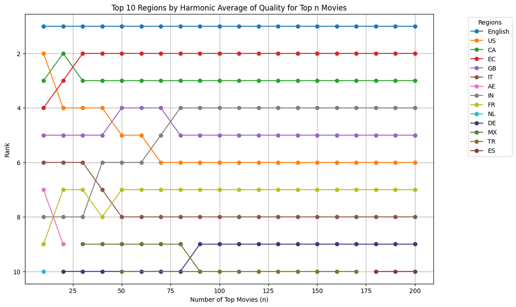

```python
# List to store results for plotting
region_rankings = {}

# Define a color palette with 20 colors
colors = [
    '#1f77b4', '#ff7f0e', '#2ca02c', '#d62728', '#9467bd',
    '#8c564b', '#e377c2', '#7f7f7f', '#bcbd22', '#17becf',
    '#393b79', '#637939', '#8c6d31', '#843c39', '#7b4173',
    '#ce6dbd', '#6b6ecf', '#b5cf6b', '#bd9e39', '#9c9ede'
]

# Create a mapping of region to color
region_color_map = {}

# Loop over different values of n
for n in range(10, 210, 10):
    region_harmonic_averages = []

    # Calculate the harmonic average for each region
    for region, group in df_exploded.groupby('region'):
        if len(group) >= n:
            top_n_movies = group.nlargest(n, 'quality')
            harmonic_avg = ef.harmonic_average(top_n_movies['quality'])
            region_harmonic_averages.append((region, harmonic_avg))

    # Sort regions by harmonic average
    region_harmonic_averages.sort(key=lambda x: x[1], reverse=True)

    # Store the rankings
    for rank, (region, avg) in enumerate(region_harmonic_averages[:10], start=1):
        if region not in region_rankings:
            region_rankings[region] = []
        region_rankings[region].append((n, rank))
        # Assign a color to each region
        if region not in region_color_map:
            color_index = len(region_color_map) % len(colors)
            region_color_map[region] = colors[color_index]

# Plotting the rankings
plt.figure(figsize=(12, 8))
regions_to_plot = {region: ranks for region, ranks in region_rankings.items() if ranks}

for region, ranks in regions_to_plot.items():
    n_vals, rank_vals = zip(*ranks)
    plt.plot(n_vals, rank_vals, marker='o', label=region, color=region_color_map[region])

plt.gca().invert_yaxis()  # Invert y-axis to have rank 1 at the top
plt.xlabel('Number of Top Movies (n)')
plt.ylabel('Rank')
plt.title('Top 10 Regions by Harmonic Average of Quality for Top n Movies')
plt.legend(title='Regions', loc='upper right', bbox_to_anchor=(1.2, 1))
plt.grid(True)
plt.show()
```

# Task 2

Na początku musimy znowu połączyć tabelę z numVotes, zeby policzyć weak impact

### Weak Impact

```python
weak_impact = df_exploded.merge(title_ratings, left_on='tconst', right_on='tconst', how='left')
```

```python
wi = weak_impact.groupby('region')['numVotes'].sum().reset_index()

# Sort by the sum of 'quality' in descending order to create a ranking
ranking_weak_impact = wi.sort_values(by='numVotes', ascending=False).reset_index(drop=True)

# Add a ranking column
ranking_weak_impact['Rank'] = ranking_weak_impact.index + 1

# Display the ranking
print(ranking_weak_impact)

print('Miejsce Polski w tym rankingu to: ', ranking_weak_impact[ranking_weak_impact['region'] == 'PL'].index + 1)
```

```
      region   numVotes  Rank
0    English  230701552     1
1         US   11386607     2
2         EC    9775456     3
3         CA    6500542     4
4         GB    4969343     5
..       ...        ...   ...
158       JM         14   159
159       CG         12   160
160       LS         12   161
161       SC          9   162
162       TD          8   163

[163 rows x 3 columns]
Miejsce Polski w tym rankingu to:  Index([26], dtype='int64')
```

### Strong impact

```python
region_harmonic_averages = df_exploded.groupby('region')['quality'].agg(ef.harmonic_average).reset_index()
region_harmonic_averages.columns = ['region', 'strongImpact']
region_harmonic_averages = region_harmonic_averages.sort_values(by='strongImpact', ascending=False)
region_harmonic_averages = region_harmonic_averages.reset_index()
region_harmonic_averages
```

|  | index | region | strongImpact |
| --- | --- | --- | --- |
| 0 | 18 | BT | 56.139956 |
| 1 | 137 | TJ | 42.927960 |
| 2 | 151 | XAS | 41.773461 |
| 3 | 153 | XPI | 37.361355 |
| 4 | 154 | XSA | 37.121008 |
| ... | ... | ... | ... |
| 158 | 124 | SD | 13.023438 |
| 159 | 114 | PK | 12.281039 |
| 160 | 134 | TD | 10.813096 |
| 161 | 99 | MV | 9.908027 |
| 162 | 123 | SC | 7.910008 |

163 rows × 3 columns

Mozna tez sprawdzić, ze dla średniej kwadratowej większe znaczenie ma liczba dobrych filmów niz szansa na "niefrafienie słabego dzieła".

```python
region_harmonic_averages = df_exploded.groupby('region')['quality'].agg(ef.quadratic_average).reset_index()
region_harmonic_averages.columns = ['region', 'strongImpact']
region_harmonic_averages = region_harmonic_averages.sort_values(by='strongImpact', ascending=False)
region_harmonic_averages = region_harmonic_averages.reset_index()
region_harmonic_averages['rankStrongIm'] = region_harmonic_averages['strongImpact'].rank(ascending=False, method='first')
region_harmonic_averages
```

|  | index | region | strongImpact | rankStrongIm |
| --- | --- | --- | --- | --- |
| 0 | 18 | BT | 56.139956 | 1.0 |
| 1 | 88 | LY | 48.984430 | 2.0 |
| 2 | 137 | TJ | 47.764160 | 3.0 |
| 3 | 0 | AE | 45.992078 | 4.0 |
| 4 | 44 | English | 45.233450 | 5.0 |
| ... | ... | ... | ... | ... |
| 158 | 73 | KE | 14.239398 | 159.0 |
| 159 | 22 | CG | 13.915477 | 160.0 |
| 160 | 99 | MV | 13.908418 | 161.0 |
| 161 | 134 | TD | 10.813096 | 162.0 |
| 162 | 123 | SC | 7.910008 | 163.0 |

163 rows × 4 columns

Uzyjemy teraz danych ze strony World Bank Group https://datacatalog.worldbank.org/search/dataset/0038130 dotycząch GDP za rok 2024, które lekko nalezało przerobić, zeby mozna bylo poprawnie wczytac jako plik .csv.

```python
#GDP = pd.read_csv('GDP.csv')
GDP = GDP.rename(columns={'id': 'rankGDP', 'region' : 'regionGDP', ' GDP' : 'GDP'})
GDP.head(5)
```

|  | regionGDP | rankGDP | fullName | GDP | Unnamed: 4 |
| --- | --- | --- | --- | --- | --- |
| 0 | USA | 1.0 | United States | 27,360,935 | NaN |
| 1 | CHN | 2.0 | China | 17,794,782 | NaN |
| 2 | DEU | 3.0 | Germany | 4,456,081 | NaN |
| 3 | JPN | 4.0 | Japan | 4,212,945 | NaN |
| 4 | IND | 5.0 | India | 3,549,919 | NaN |

W takim razie będziemy potrzebowali jeszcze znalezionego gdzieś przekładu ze skrótów 3 literowych na 2 literowe. Znaleziony na https://github.com/lukes/ISO-3166-Countries-with-Regional-Codes/blob/master/all/all.csv zaimportujemy do naszego notatnika.

```python
abb = pd.read_csv('all.csv')
abb = abb.rename(columns={'alpha-3': 'regionAbb3', 'alpha-2': 'regionAbb2'})[['regionAbb3', 'regionAbb2']]
abb.head(5)
```

|  | regionAbb3 | regionAbb2 |
| --- | --- | --- |
| 0 | AFG | AF |
| 1 | ALA | AX |
| 2 | ALB | AL |
| 3 | DZA | DZ |
| 4 | ASM | AS |

Pobierzemy teraz dane dotyczące populacji ze strony https://www.kaggle.com/datasets/iamsouravbanerjee/world-population-dataset?resource=download.

```python
#pop = pd.read_csv('world_population.csv')
pop = pop[['Rank', 'CCA3', '2022 Population']]
pop = pop.rename(columns={'Rank': 'rankPop', 'CCA3': 'regionPop', '2022 Population': 'pop'})
pop.head(5)
```

|  | rankPop | regionPop | pop |
| --- | --- | --- | --- |
| 0 | 36 | AFG | 41128771 |
| 1 | 138 | ALB | 2842321 |
| 2 | 34 | DZA | 44903225 |
| 3 | 213 | ASM | 44273 |
| 4 | 203 | AND | 79824 |

```python
task_2 = GDP.merge(abb, left_on='regionGDP', right_on='regionAbb3', how='left')
task_2 = task_2.merge(pop, left_on='regionGDP', right_on='regionPop', how='left')
task_2 = task_2.merge(region_harmonic_averages, left_on='regionAbb2', right_on='region', how='left')
task_2.dropna(subset=['regionAbb3', 'regionPop', 'region', 'GDP'])
number = "-"
print(ef.convert_gdp_format(number))
task_2['GDP'] = task_2['GDP'].apply(ef.convert_gdp_format)
task_2
```

```
nan
```

|  | regionGDP | rankGDP | fullName | GDP | Unnamed: 4 | regionAbb3 | regionAbb2 | rankPop | regionPop | pop | index | region | strongImpact | rankStrongIm |
| --- | --- | --- | --- | --- | --- | --- | --- | --- | --- | --- | --- | --- | --- | --- |
| 0 | USA | 1.0 | United States | 27360935.0 | NaN | USA | US | 3.0 | USA | 3.382899e+08 | 145.0 | US | 27.822812 | 69.0 |
| 1 | CHN | 2.0 | China | 17794782.0 | NaN | CHN | CN | 1.0 | CHN | 1.425887e+09 | 27.0 | CN | 21.588823 | 128.0 |
| 2 | DEU | 3.0 | Germany | 4456081.0 | NaN | DEU | DE | 19.0 | DEU | 8.336984e+07 | 35.0 | DE | 28.990059 | 51.0 |
| 3 | JPN | 4.0 | Japan | 4212945.0 | NaN | JPN | JP | 11.0 | JPN | 1.239517e+08 | 72.0 | JP | 30.436798 | 39.0 |
| 4 | IND | 5.0 | India | 3549919.0 | NaN | IND | IN | 2.0 | IND | 1.417173e+09 | 66.0 | IN | 27.377685 | 75.0 |
| ... | ... | ... | ... | ... | ... | ... | ... | ... | ... | ... | ... | ... | ... | ... |
| 212 | PRK | NaN | Korea, Dem. People's Rep. | NaN | NaN | PRK | KP | 56.0 | PRK | 2.606942e+07 | 76.0 | KP | 19.295208 | 144.0 |
| 213 | MNP | NaN | Northern Mariana Islands | NaN | NaN | MNP | MP | NaN | NaN | NaN | NaN | NaN | NaN | NaN |
| 214 | SSD | NaN | South Sudan | NaN | NaN | SSD | SS | 86.0 | SSD | 1.091316e+07 | NaN | NaN | NaN | NaN |
| 215 | VEN | NaN | Venezuela, RB | NaN | NaN | VEN | VE | 51.0 | VEN | 2.830170e+07 | 149.0 | VE | 24.127660 | 109.0 |
| 216 | YEM | NaN | Yemen, Rep. | NaN | NaN | YEM | YE | 46.0 | YEM | 3.369661e+07 | NaN | NaN | NaN | NaN |

217 rows × 14 columns

```python
task_2['GDP_pop'] = task_2['GDP'] / task_2['pop']
task_2.sort_values('GDP_pop', ascending=False).reset_index()
task_2['rankGDP_pop'] = task_2.index + 1
task_2.dropna(subset=['GDP_pop', 'rankStrongIm'], inplace=True)
task_2['diff_Strong_GDP'] = task_2['rankStrongIm'] - task_2['rankGDP']
task_2
```

|  | regionGDP | rankGDP | fullName | GDP | Unnamed: 4 | regionAbb3 | regionAbb2 | rankPop | regionPop | pop | index | region | strongImpact | rankStrongIm | GDP_pop | rankGDP_pop | diff_Strong_GDP |
| --- | --- | --- | --- | --- | --- | --- | --- | --- | --- | --- | --- | --- | --- | --- | --- | --- | --- |
| 0 | USA | 1.0 | United States | 27360935.0 | NaN | USA | US | 3.0 | USA | 3.382899e+08 | 145.0 | US | 27.822812 | 69.0 | 0.080880 | 1 | 68.0 |
| 1 | CHN | 2.0 | China | 17794782.0 | NaN | CHN | CN | 1.0 | CHN | 1.425887e+09 | 27.0 | CN | 21.588823 | 128.0 | 0.012480 | 2 | 126.0 |
| 2 | DEU | 3.0 | Germany | 4456081.0 | NaN | DEU | DE | 19.0 | DEU | 8.336984e+07 | 35.0 | DE | 28.990059 | 51.0 | 0.053450 | 3 | 48.0 |
| 3 | JPN | 4.0 | Japan | 4212945.0 | NaN | JPN | JP | 11.0 | JPN | 1.239517e+08 | 72.0 | JP | 30.436798 | 39.0 | 0.033989 | 4 | 35.0 |
| 4 | IND | 5.0 | India | 3549919.0 | NaN | IND | IN | 2.0 | IND | 1.417173e+09 | 66.0 | IN | 27.377685 | 75.0 | 0.002505 | 5 | 70.0 |
| ... | ... | ... | ... | ... | ... | ... | ... | ... | ... | ... | ... | ... | ... | ... | ... | ... | ... |
| 174 | GRL | 175.0 | Greenland | 3236.0 | NaN | GRL | GL | 208.0 | GRL | 5.646600e+04 | 52.0 | GL | 35.862565 | 15.0 | 0.057309 | 175 | -160.0 |
| 176 | BTN | 177.0 | Bhutan | 2898.0 | NaN | BTN | BT | 165.0 | BTN | 7.824550e+05 | 18.0 | BT | 56.139956 | 1.0 | 0.003704 | 177 | -176.0 |
| 183 | SYC | 184.0 | Seychelles | 2141.0 | NaN | SYC | SC | 196.0 | SYC | 1.071180e+05 | 123.0 | SC | 7.910008 | 163.0 | 0.019987 | 184 | -21.0 |
| 184 | LSO | 185.0 | Lesotho | 2046.0 | NaN | LSO | LS | 147.0 | LSO | 2.305825e+06 | 84.0 | LS | 15.903403 | 157.0 | 0.000887 | 185 | -28.0 |
| 186 | GNB | 187.0 | Guinea-Bissau | 1966.0 | NaN | GNB | GW | 149.0 | GNB | 2.105566e+06 | 56.0 | GW | 32.112326 | 27.0 | 0.000934 | 187 | -160.0 |

144 rows × 17 columns

# Task 3

Porownamy moich ulubionych tworców: rezysera Wesa Andersona, aktora Christiana Bale'a oraz aktora Edwarda Nortona. Za pomocą dostępnej wiedzy o roku urodzenia tych tworcow znajduje ich w naszej bazie danych.

```python
name_basics = pliki[klucze[3]]
wes_and = name_basics[name_basics['primaryName'].str.contains('Wes Anderson', na=False) & name_basics['birthYear'].str.contains('1969', case=False, na=False)]
chr_bal = name_basics[name_basics['primaryName'].str.contains('Christian Bale', na=False) & name_basics['birthYear'].str.contains('1974', case=False, na=False)]
edw_nor = name_basics[name_basics['primaryName'].str.contains('Edward Norton', na=False) & name_basics['birthYear'].str.contains('1969', case=False, na=False)]
```

Zobaczmy w jakich filmach brali oni udział

```python
wes_and_movies = wes_and['knownForTitles'].iloc[0].split(',')
chr_bal_movies = chr_bal['knownForTitles'].iloc[0].split(',')
edw_nor_movies = edw_nor['knownForTitles'].iloc[0].split(',')
```

znajdzmy indeks naszych twórców

```python
print('Wes: ', wes_and['nconst'], ', Chris: ', chr_bal['nconst'], ', Edward: ', edw_nor['nconst'])
```

```
Wes:  26444    nm0027572
Name: nconst, dtype: object , Chris:  287    nm0000288
Name: nconst, dtype: object , Edward:  1568    nm0001570
Name: nconst, dtype: object
```

```python
title_akas = pliki[klucze[2]]
wes_and_title_akas = title_akas[title_akas['titleId'].isin(wes_and_movies)]
print(wes_and_title_akas[wes_and_title_akas['isOriginalTitle'] == 1]['title'])
chr_bal_title_akas = title_akas[title_akas['titleId'].isin(chr_bal_movies)]
print(chr_bal_title_akas[chr_bal_title_akas['isOriginalTitle'] == 1]['title'])
edw_nor_title_akas = title_akas[title_akas['titleId'].isin(edw_nor_movies)]
print(edw_nor_title_akas[edw_nor_title_akas['isOriginalTitle'] == 1]['title'])
```

```
1121984                                              Rushmore
1597204                                  The Royal Tenenbaums
2119652                                     Fantastic Mr. Fox
46454800    The French Dispatch of the Liberty, Kansas Eve...
Name: title, dtype: object
1937184             Batman Begins
2228783           The Dark Knight
13197211    The Dark Knight Rises
21655301          American Hustle
Name: title, dtype: object
```

```
1050723                                         Primal Fear
1083713                                  American History X
1155977                                          Fight Club
28443569    Birdman or (The Unexpected Virtue of Ignorance)
Name: title, dtype: object
```

```python
title_principals = pliki[klucze[1]]
ws_movies = title_principals[(title_principals['nconst'] == 'nm0027572') & (title_principals['category'] == 'director')]
ws_movies = ws_movies.merge(title_r_p, left_on= 'tconst', right_on = 'tconst', how='left')
title_akas = title_akas[title_akas['isOriginalTitle'] == 1]
ws_movies = ws_movies.merge(title_akas, left_on='tconst', right_on='titleId', how='left')
ws_movies = ws_movies[ws_movies['titleType'].isin(['movie', 'tvMovie'])]
ws_movies =ws_movies[['tconst', 'nconst', 'quality', 'title']].drop_duplicates()
ws_movies = ws_movies.sort_values('quality', ascending=False)
ws_movies = ws_movies.head(10)
ws_movies
```

|  | tconst | nconst | quality | title |
| --- | --- | --- | --- | --- |
| 2 | tt0128445 | nm0027572 | 92.727866 | Rushmore |
| 1 | tt0115734 | nm0027572 | 78.231875 | Bottle Rocket |

```python
title_principals = pliki[klucze[1]]
cb_movies = title_principals[(title_principals['nconst'] == 'nm0000288') & (title_principals['category'] == 'actor')]
cb_movies = cb_movies.merge(title_r_p, left_on= 'tconst', right_on = 'tconst', how='left')
title_akas = title_akas[title_akas['isOriginalTitle'] == 1]
cb_movies = cb_movies.merge(title_akas, left_on='tconst', right_on='titleId', how='left')
cb_movies = cb_movies[cb_movies['titleType'].isin(['movie', 'tvMovie'])]
cb_movies = cb_movies[['quality', 'title']].drop_duplicates()
cb_movies = cb_movies.sort_values('quality', ascending=False)
cb_movies = cb_movies.head(10)
cb_movies
```

|  | quality | title |
| --- | --- | --- |
| 1 | 90.959818 | Empire of the Sun |
| 10 | 81.924915 | Pocahontas |
| 8 | 80.790565 | Little Women |
| 15 | 72.847316 | Velvet Goldmine |
| 6 | 69.212387 | Newsies |
| 7 | 65.433774 | Swing Kids |
| 16 | 65.334674 | A Midsummer Night's Dream |
| 4 | 60.965100 | Treasure Island |
| 11 | 58.599182 | The Portrait of a Lady |
| 2 | 54.912110 | Mio min Mio |

```python
title_principals = pliki[klucze[1]]
en_movies = title_principals[(title_principals['nconst'] == 'nm0001570') & (title_principals['category'] == 'actor')]
en_movies = en_movies.merge(title_r_p, left_on= 'tconst', right_on = 'tconst', how='left')
title_akas = title_akas[title_akas['isOriginalTitle'] == 1]
en_movies = en_movies.merge(title_akas, left_on='tconst', right_on='titleId', how='left')
en_movies = en_movies[en_movies['titleType'].isin(['movie', 'tvMovie'])]
en_movies = en_movies[['tconst', 'nconst', 'quality', 'title']].drop_duplicates()
en_movies = en_movies.sort_values('quality', ascending=False)
en_movies = en_movies.head(10)
en_movies
```

|  | tconst | nconst | quality | title |
| --- | --- | --- | --- | --- |
| 6 | tt0137523 | nm0001570 | 129.077869 | Fight Club |
| 4 | tt0120586 | nm0001570 | 118.932956 | American History X |
| 2 | tt0117381 | nm0001570 | 95.673794 | Primal Fear |
| 5 | tt0128442 | nm0001570 | 87.515150 | Rounders |
| 1 | tt0117318 | nm0001570 | 84.130569 | The People vs. Larry Flynt |
| 0 | tt0116242 | nm0001570 | 70.928931 | Everyone Says I Love You |
| 7 | tt0141699 | nm0001570 | 37.758652 | Out of the Past |

```python
quality_values = ws_movies['quality']
quality_values = quality_values.dropna()
quality_values = np.array(quality_values)
print('Wes Anderson score is: ', ef.quadratic_average(quality_values))
quality_values = cb_movies['quality']
quality_values = quality_values.dropna()
quality_values = np.array(quality_values)
print('Christian Bale score is: ', ef.quadratic_average(quality_values))
quality_values = en_movies['quality']
quality_values = quality_values.dropna()
quality_values = np.array(quality_values)
print('Edward Norton score is: ', ef.quadratic_average(quality_values))
```

```
Wes Anderson score is:  85.78660531451003
Christian Bale score is:  70.94062838181283
Edward Norton score is:  93.46741389400512
```